# Practical Machine Learning Course Project

Written by Jeff W (lachrymator) on July 24, 2014

## Synopsis

Using devices such as Jawbone Up, Nike FuelBand, and Fitbit it is now possible to collect a large amount of data about personal activity relatively inexpensively. These type of devices are part of the quantified self movement - a group of enthusiasts who take measurements about themselves regularly to improve their health, to find patterns in their behavior, or because they are tech geeks. One thing that people regularly do is quantify how much of a particular activity they do, but they rarely quantify how well they do it. In this project, your goal will be to use data from accelerometers on the belt, forearm, arm, and dumbell of 6 participants. They were asked to perform barbell lifts correctly and incorrectly in 5 different ways. More information is available from the website here: http://groupware.les.inf.puc-rio.br/har (see the section on the Weight Lifting Exercise Dataset).

The goal of this project is to develop a machine learning algorthm to predict the manner in which subjects did the exercise. (classe variable), using data from the dataset.

## Getting the data

Data is downloaded from the following URLs, if necessary

```r
library(caret);library(randomForest);library(doParallel);options(width = 400)

setwd("C:/Coursera/PractMachineLearn")
trainfileurl<- "https://d396qusza40orc.cloudfront.net/predmachlearn/pml-training.csv"
testfileurl<- "https://d396qusza40orc.cloudfront.net/predmachlearn/pml-testing.csv"
if(!file.exists("data/train.csv")) download.file(trainfileurl, "data/train.csv")
if(!file.exists("data/test.csv")) download.file(testfileurl, "data/test.csv")
trainset <- read.csv("data/train.csv", na.strings=c("NA",""), stringsAsFactors=F)
testset <- read.csv("data/test.csv", na.strings=c("NA",""), stringsAsFactors=F)

### Code for Parallel Processing in Windows
cl<-makeCluster(detectCores())
registerDoParallel(cl)
```

## Cleaning the data

```r
naframe <-data.frame(names(trainset))
naframe$MinVal <- apply(trainset, 2, range, na.rm=T)[1,]
naframe$MaxVal <- apply(trainset, 2, range, na.rm=T)[2,]
naframe$sum_na_trainset <- colSums(is.na(trainset))
naframe$sum_na_testset <- colSums(is.na(testset))
naframe
```

```
##              names.trainset.           MinVal           MaxVal sum_na_trainset sum_na_testset
## 1                          X                1            19622               0              0
## 2                  user_name           adelmo            pedro               0              0
## 3       raw_timestamp_part_1       1322489605       1323095081               0              0
## 4       raw_timestamp_part_2              294           998801               0              0
## 5             cvtd_timestamp 02/12/2011 13:32 30/11/2011 17:12               0              0
## 6                 new_window               no              yes               0              0
## 7                 num_window                1              864               0              0
## 8                  roll_belt           -10.20           162.00               0              0
## 9                 pitch_belt           -27.00            60.30               0              0
## 10                  yaw_belt          -167.00           179.00               0              0
## 11          total_accel_belt                0               29               0              0
## 12        kurtosis_roll_belt        -0.016850         7.515290           19216             20
## 13       kurtosis_picth_belt        -0.021887         9.896970           19216             20
## 14         kurtosis_yaw_belt          #DIV/0!          #DIV/0!           19216             20
```

[output cut: 146 more lines]

We can see that both the training and test set have NA values in the same places, so we can eliminate those features without losing any predictive data.

Also, we are uninterested in columns 1 to 7 for the purpose of prediction. These will be removed. The remainder of the columns are forced into numeric vectors.

```r
for(i in 7:159) {
     trainset[,i]<-as.numeric(trainset[,i])
     testset[,i]<-as.numeric(testset[,i])
}
trainset[,160]<-as.factor(trainset[,160])
testset[,160]<-as.factor(testset[,160])
colindex<- colSums(is.na(trainset))==0
colindex[1:7]=FALSE
trainset<-trainset[,colindex]
testset<-testset[,colindex]

str(trainset)
```

```
## 'data.frame':    19622 obs. of  53 variables:
##  $ roll_belt           : num  1.41 1.41 1.42 1.48 1.48 1.45 1.42 1.42 1.43 1.45 ...
##  $ pitch_belt          : num  8.07 8.07 8.07 8.05 8.07 8.06 8.09 8.13 8.16 8.17 ...
##  $ yaw_belt            : num  -94.4 -94.4 -94.4 -94.4 -94.4 -94.4 -94.4 -94.4 -94.4 -94.4 ...
##  $ total_accel_belt    : num  3 3 3 3 3 3 3 3 3 3 ...
##  $ gyros_belt_x        : num  0 0.02 0 0.02 0.02 0.02 0.02 0.02 0.02 0.03 ...
##  $ gyros_belt_y        : num  0 0 0 0 0.02 0 0 0 0 0 ...
##  $ gyros_belt_z        : num  -0.02 -0.02 -0.02 -0.03 -0.02 -0.02 -0.02 -0.02 -0.02 0 ...
##  $ accel_belt_x        : num  -21 -22 -20 -22 -21 -21 -22 -22 -20 -21 ...
##  $ accel_belt_y        : num  4 4 5 3 2 4 3 4 2 4 ...
##  $ accel_belt_z        : num  22 22 23 21 24 21 21 21 24 22 ...
##  $ magnet_belt_x       : num  -3 -7 -2 -6 -6 0 -4 -2 1 -3 ...
##  $ magnet_belt_y       : num  599 608 600 604 600 603 599 603 602 609 ...
##  $ magnet_belt_z       : num  -313 -311 -305 -310 -302 -312 -311 -313 -312 -308 ...
##  $ roll_arm            : num  -128 -128 -128 -128 -128 -128 -128 -128 -128 -128 ...
```

[output cut: 39 more lines]

## Building the algorithm

To get a better sense of what descriptors are important for prediction, we can look at a plot of all the predictors that have larger variances. (percentUnique)

```r
nearZeroVar(trainset[,1:52], saveMetrics = T)
```

```
##                      freqRatio percentUnique zeroVar   nzv
## roll_belt                1.102        6.7781   FALSE FALSE
## pitch_belt               1.036        9.3772   FALSE FALSE
## yaw_belt                 1.058        9.9735   FALSE FALSE
## total_accel_belt         1.063        0.1478   FALSE FALSE
## gyros_belt_x             1.059        0.7135   FALSE FALSE
## gyros_belt_y             1.144        0.3516   FALSE FALSE
## gyros_belt_z             1.066        0.8613   FALSE FALSE
## accel_belt_x             1.055        0.8358   FALSE FALSE
## accel_belt_y             1.114        0.7288   FALSE FALSE
## accel_belt_z             1.079        1.5238   FALSE FALSE
## magnet_belt_x            1.090        1.6665   FALSE FALSE
## magnet_belt_y            1.100        1.5187   FALSE FALSE
## magnet_belt_z            1.006        2.3290   FALSE FALSE
## roll_arm                52.338       13.5256   FALSE FALSE
## pitch_arm               87.256       15.7323   FALSE FALSE
## yaw_arm                 33.029       14.6570   FALSE FALSE
## total_accel_arm          1.025        0.3364   FALSE FALSE
## gyros_arm_x              1.016        3.2769   FALSE FALSE
## gyros_arm_y              1.454        1.9162   FALSE FALSE
## gyros_arm_z              1.111        1.2639   FALSE FALSE
## accel_arm_x              1.017        3.9598   FALSE FALSE
## accel_arm_y              1.140        2.7367   FALSE FALSE
## accel_arm_z              1.128        4.0363   FALSE FALSE
## magnet_arm_x             1.000        6.8240   FALSE FALSE
## magnet_arm_y             1.057        4.4440   FALSE FALSE
## magnet_arm_z             1.036        6.4468   FALSE FALSE
## roll_dumbbell            1.022       84.2065   FALSE FALSE
## pitch_dumbbell           2.277       81.7450   FALSE FALSE
## yaw_dumbbell             1.132       83.4828   FALSE FALSE
## total_accel_dumbbell     1.073        0.2191   FALSE FALSE
## gyros_dumbbell_x         1.003        1.2282   FALSE FALSE
## gyros_dumbbell_y         1.265        1.4168   FALSE FALSE
## gyros_dumbbell_z         1.060        1.0498   FALSE FALSE
## accel_dumbbell_x         1.018        2.1659   FALSE FALSE
## accel_dumbbell_y         1.053        2.3749   FALSE FALSE
## accel_dumbbell_z         1.133        2.0895   FALSE FALSE
## magnet_dumbbell_x        1.098        5.7486   FALSE FALSE
## magnet_dumbbell_y        1.198        4.3013   FALSE FALSE
## magnet_dumbbell_z        1.021        3.4451   FALSE FALSE
## roll_forearm            11.589       11.0896   FALSE FALSE
## pitch_forearm           65.983       14.8558   FALSE FALSE
## yaw_forearm             15.323       10.1468   FALSE FALSE
## total_accel_forearm      1.129        0.3567   FALSE FALSE
## gyros_forearm_x          1.059        1.5187   FALSE FALSE
## gyros_forearm_y          1.037        3.7764   FALSE FALSE
## gyros_forearm_z          1.123        1.5646   FALSE FALSE
## accel_forearm_x          1.126        4.0465   FALSE FALSE
## accel_forearm_y          1.059        5.1116   FALSE FALSE
## accel_forearm_z          1.006        2.9559   FALSE FALSE
## magnet_forearm_x         1.012        7.7668   FALSE FALSE
## magnet_forearm_y         1.247        9.5403   FALSE FALSE
## magnet_forearm_z         1.000        8.5771   FALSE FALSE
```

The features that have over 10 percentUnique will then be plotted to see how strongly they predict classes.

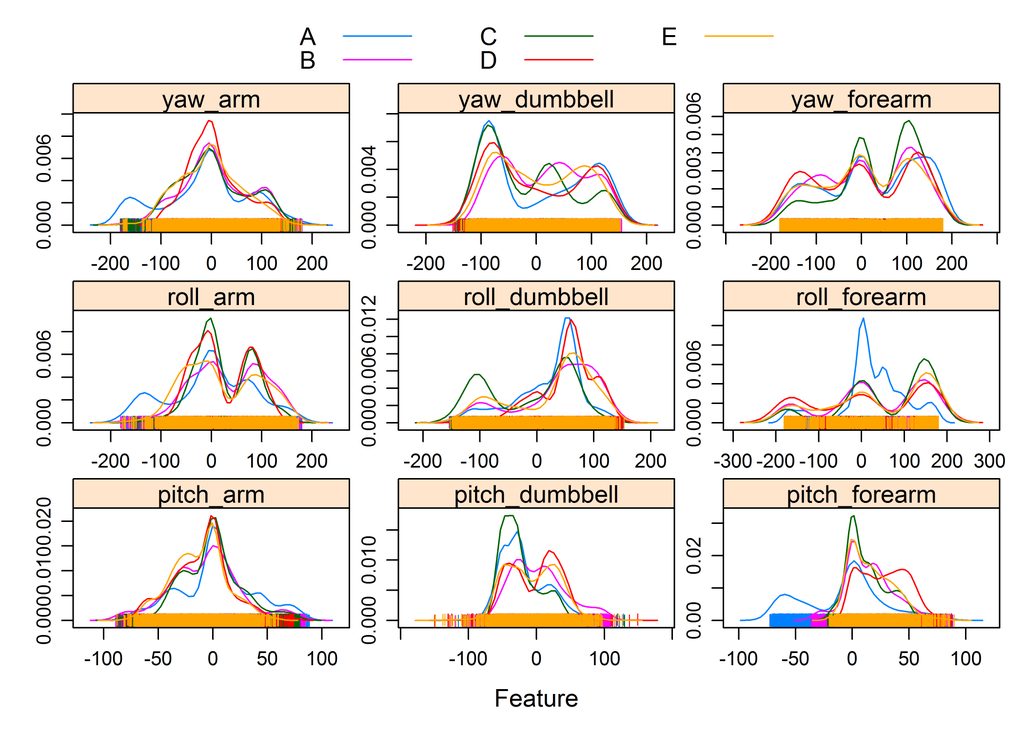

```r
plot1 <- featurePlot(x=trainset[,nearZeroVar(trainset, saveMetrics = T)$percentUnique > 10],
            y=trainset$classe,
            plot = "density",
            scales = list(x = list(relation="free"),
                          y = list(relation="free")),
            adjust = 1.5,
            pch = "|",
            layout = c(3,3),
            auto.key=list(columns=3))
plot1
```

**Figure 1** The most variable features plotted against classe

From eyeballing it, most features do not seem to be individually strong predictors of classe. Let the algorithms decide.

We will look at two algorithms - Gradient Boosting and Random Forests to predict using 5-fold cross-validation. The caret package will be used for the boosted regression modelling, and randomForest will be used for the random forest modelling.

```r
seed = 1  #Setting the seed for reproducibility
set.seed(seed)

system.time({
gbmModel <- train(classe~., data=trainset,
                method = "gbm",
                verbose = F,
                trControl = trainControl(method = "cv",
                                         number = 5,
                                         repeats = 5))



})
```

```
##    user  system elapsed
##   33.82    0.18  131.46
```

```r
gbmModel; gbmModel$results
```

[output not shown]

```
##   shrinkage interaction.depth n.trees Accuracy  Kappa AccuracySD  KappaSD
## 1       0.1                 1      50   0.7544 0.6886   0.008447 0.010621
## 4       0.1                 2      50   0.8571 0.8189   0.004442 0.005700
## 7       0.1                 3      50   0.8988 0.8719   0.004329 0.005458
## 2       0.1                 1     100   0.8210 0.7733   0.006279 0.007963
## 5       0.1                 2     100   0.9074 0.8828   0.003709 0.004735
## 8       0.1                 3     100   0.9440 0.9291   0.003479 0.004395
## 3       0.1                 1     150   0.8537 0.8149   0.004900 0.006237
## 6       0.1                 2     150   0.9346 0.9173   0.003519 0.004468
## 9       0.1                 3     150   0.9617 0.9516   0.002910 0.003687
```

The generalized boosting model therefore had a 5-fold cross-validated error estimate of **96.2**% Accuracy.

```r
system.time({
rfModel <- train(classe~., data=trainset,
                method = "rf",
                trControl = trainControl(method = "cv",
                                         number = 5,
                                         repeats = 5))

})
```

```
##    user  system elapsed
##   40.36    0.36  292.86
```

```r
rfModel; rfModel$results
```

[output not shown]

```
##   mtry Accuracy  Kappa AccuracySD  KappaSD
## 1    2   0.9945 0.9930   0.001598 0.002022
## 2   27   0.9942 0.9927   0.001754 0.002220
## 3   52   0.9889 0.9860   0.001494 0.001890
```

Therefore, we will use the random forest model to predict the test set. The importance of variables for the model:

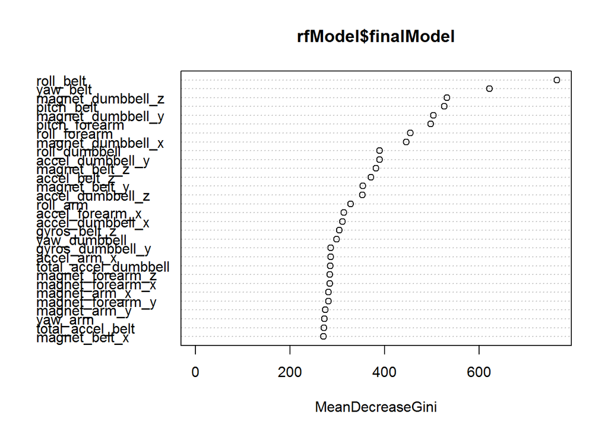

```r
varImpPlot(rfModel$finalModel)
```

**Figure 2** Variable importance for the random Forest model

We can re-create the plot from before and see how the variables decided by random Forest predict the classes.

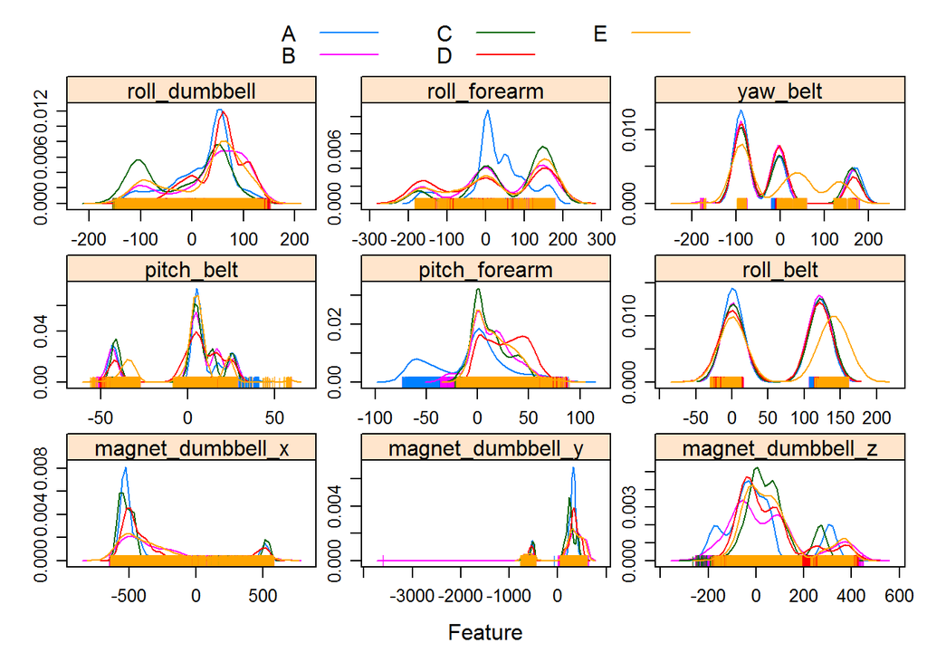

```r
varimp <- data.frame(importance(rfModel$finalModel))
varimp$feats <- rownames(varimp)
varimp <- varimp[order(varimp$MeanDecreaseGini, decreasing=T),]
varimp <- varimp[1:9,]

plot2 <- featurePlot(x=trainset[,varimp$feats],
            y=trainset$classe,
            plot = "density",
            scales = list(x = list(relation="free"),
                          y = list(relation="free")),
            adjust = 1.5,
            pch = "|",
            layout = c(3,3),
            auto.key=list(columns=3))
plot2
```

**Figure 3** Top 9 predictors by randomForest plotted against the classes

By visual inspection, we can see that each of these random Forest chosen predictors separates roughly only one of the classes.

## Prediction of the Test Set

```r
rfModel$finalModel
```

```
##
## Call:
##  randomForest(x = x, y = y, mtry = param$mtry)
##                Type of random forest: classification
##                      Number of trees: 500
## No. of variables tried at each split: 2
##
##         OOB estimate of  error rate: 0.42%
## Confusion matrix:
##      A    B    C    D    E class.error
## A 5578    1    0    0    1   0.0003584
## B   11 3783    3    0    0   0.0036871
## C    0   17 3404    1    0   0.0052601
## D    0    0   42 3172    2   0.0136816
## E    0    0    0    5 3602   0.0013862
```

```r
answers<-data.frame(cbind(testset$problem_id,
                          as.character(predict(rfModel, testset[,-53])),
                          as.character(predict(gbmModel, testset[,-53]))))
names(answers)<- c("problem_id", "predicted-RF","predicted-GBM")
answers
```

```
##    problem_id predicted-RF predicted-GBM
## 1           1            B             B
## 2           2            A             A
## 3           3            B             B
## 4           4            A             A
## 5           5            A             A
## 6           6            E             E
## 7           7            D             D
## 8           8            B             B
## 9           9            A             A
## 10         10            A             A
## 11         11            B             B
## 12         12            C             C
## 13         13            B             B
## 14         14            A             A
## 15         15            E             E
## 16         16            E             E
## 17         17            A             A
## 18         18            B             B
## 19         19            B             B
## 20         20            B             B
```

In the end, both models predicted the same answer. The answers were then split into individual files for submission

```r
pml_write_files = function(x){
  n = length(x)
  for(i in 1:n){
    filename = paste0("problem_id_",i,".txt")
    write.table(x[i],file=filename,quote=FALSE,row.names=FALSE,col.names=FALSE)
  }
}

pml_write_files(as.character(predict(rfModel$finalModel, testset)))
```